# Heart Disease Prediction: Binary Classification with Logistic Regression and Random Forest Classifier

In this notebook we will use the UCI Heart Disease ([link here](https://www.kaggle.com/datasets/redwankarimsony/heart-disease-data)) dataset from kaggle to do basic analysis and simple models effectiveness comparison

## Data reading and cleaning

### Importing required libraries

```python
import pandas as pd
import seaborn as sns
import matplotlib.pyplot as plt
```

### Reading the dataset using pandas

We will also print the infos of the dataset to get the null row count and data type for each column

```python
df = pd.read_csv("./heart_disease_uci.csv")

print(df.info())
```

```
<class 'pandas.core.frame.DataFrame'>
RangeIndex: 920 entries, 0 to 919
Data columns (total 16 columns):
 #   Column    Non-Null Count  Dtype
---  ------    --------------  -----
 0   id        920 non-null    int64
 1   age       920 non-null    int64
 2   sex       920 non-null    object
 3   dataset   920 non-null    object
 4   cp        920 non-null    object
 5   trestbps  861 non-null    float64
 6   chol      890 non-null    float64
 7   fbs       830 non-null    object
 8   restecg   918 non-null    object
 9   thalch    865 non-null    float64
 10  exang     865 non-null    object
 11  oldpeak   858 non-null    float64
 12  slope     611 non-null    object
 13  ca        309 non-null    float64
 14  thal      434 non-null    object
 15  num       920 non-null    int64
dtypes: float64(5), int64(3), object(8)
memory usage: 115.1+ KB
None
```

### Make data usable

In this step we will programmatically identify columns to exclude due to very high null value count (> 50%) and columns to where we want to fill in the null-values (making the distinction between numeric and object columns)

```python
# we get the values to drop
cols_to_drop = set(df.columns[df.isnull().mean() > 0.5])

# then the numeric and object columns
num_cols = set(df.select_dtypes(include='number').columns)
cat_cols = set(df.select_dtypes(include='object').columns)

# identify which ones have null values
num_with_nan = {c for c in num_cols if df[c].isnull().any()} - cols_to_drop
cat_with_nan = {c for c in cat_cols if df[c].isnull().any()} - cols_to_drop

print("Numeric to fill :")
print(list(num_with_nan) if len(num_with_nan) > 0 else "None")

print("Object to fill :")
print(list(cat_with_nan) if len(cat_with_nan) > 0 else "None")

print("Columns to delete (>50% NaN) :")
print(list(cols_to_drop) if len(cols_to_drop) > 0 else "None")
```

```
Numeric to fill :
['trestbps', 'thalch', 'chol', 'oldpeak']
Object to fill :
['slope', 'exang', 'restecg', 'fbs']
Columns to delete (>50% NaN) :
['thal', 'ca']
```

now let's actually do the cleaning

```python
# dropping the columns
df = df.drop(columns=list(cols_to_drop), errors='ignore')

# filling the numeric ones
for col in num_with_nan:
    df[col] = df[col].fillna(df[col].median())

# and the object ones
for col in cat_with_nan:
    df[col] = df[col].fillna(df[col].mode()[0])
```

now we should have two less columns and no null values

```python
df.info()
```

```
<class 'pandas.core.frame.DataFrame'>
RangeIndex: 920 entries, 0 to 919
Data columns (total 14 columns):
 #   Column    Non-Null Count  Dtype
---  ------    --------------  -----
 0   id        920 non-null    int64
 1   age       920 non-null    int64
 2   sex       920 non-null    object
 3   dataset   920 non-null    object
 4   cp        920 non-null    object
 5   trestbps  920 non-null    float64
 6   chol      920 non-null    float64
 7   fbs       920 non-null    bool
 8   restecg   920 non-null    object
 9   thalch    920 non-null    float64
 10  exang     920 non-null    bool
 11  oldpeak   920 non-null    float64
 12  slope     920 non-null    object
 13  num       920 non-null    int64
dtypes: bool(2), float64(4), int64(3), object(5)
memory usage: 88.2+ KB
```

## Data analysis

### Heatmap plot

We want to find the most relevant factors to the disease and for that we could use a heatmap plot to visualize the data.

*n.b.*: the `num` column represents the gravity of the disease from 0 to 4

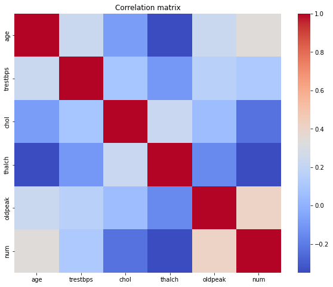

```python
num_df = df.select_dtypes(include='number').drop(columns=['id'], errors='ignore')

plt.figure(figsize=(10,8))
sns.heatmap(num_df.corr(), cmap="coolwarm")
plt.title("Correlation matrix")
plt.show()
```

we find these relationships between the columns:

with the `num` target:

positively correlated, we have:

- `oldpeak` which represents ST depression induced by exercise relative to rest
- `age` which represents the age of the patient

negatively correlated:

- `thalach` which represents the maximum heart rate achieved

between features:

negatively correlated:

- `age` and `thalach`, meaning that with the age the max heart rate decreases

### Age distribution by heart disease level

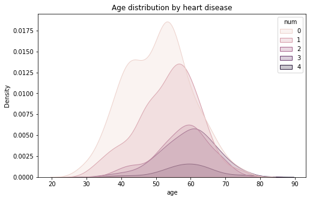

```python
plt.figure(figsize=(8,5))
sns.kdeplot(data=df, x="age", hue="num", fill=True)
plt.title("Age distribution by heart disease")
plt.show()
```

We can see that the level 1 disease patients are generally younger than more serious levels and also are the most common level of disease.

## Prediction models

We will now test two different prediction models on this dataset and compare their effectiveness in trying to identifying the main key factors of the disease and using them to predict whether a patient has the disease or not.

### Making a binary target from `num`

Making a binary target from `num` (0: healthy, 1: unhealthy) allows us to use the dataset with more classification models.

```python
df["target"] = df["num"].apply(lambda x: 1 if x > 0 else 0)
df.head()
```

|  | id | age | sex | dataset | cp | trestbps | chol | fbs | restecg | thalch | exang | oldpeak | slope | num | target |
| --- | --- | --- | --- | --- | --- | --- | --- | --- | --- | --- | --- | --- | --- | --- | --- |
| 0 | 1 | 63 | Male | Cleveland | typical angina | 145.0 | 233.0 | True | lv hypertrophy | 150.0 | False | 2.3 | downsloping | 0 | 0 |
| 1 | 2 | 67 | Male | Cleveland | asymptomatic | 160.0 | 286.0 | False | lv hypertrophy | 108.0 | True | 1.5 | flat | 2 | 1 |
| 2 | 3 | 67 | Male | Cleveland | asymptomatic | 120.0 | 229.0 | False | lv hypertrophy | 129.0 | True | 2.6 | flat | 1 | 1 |
| 3 | 4 | 37 | Male | Cleveland | non-anginal | 130.0 | 250.0 | False | normal | 187.0 | False | 3.5 | downsloping | 0 | 0 |
| 4 | 5 | 41 | Female | Cleveland | atypical angina | 130.0 | 204.0 | False | lv hypertrophy | 172.0 | False | 1.4 | upsloping | 0 | 0 |

We plot the distribution of target to see if the dataset is fairly distributed

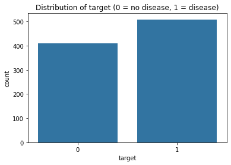

```python
plt.figure(figsize=(6,4))
sns.countplot(x="target", data=df)
plt.title("Distribution of target (0 = no disease, 1 = disease)")
plt.show()
```

and it seems to be not so bad

### Separating features and classes

When doing supervised machine learning we want to separate the inputs (called features) and outputs (called classes in classification problems).

```python
X = df.drop(columns=["target", "num", "id"], errors="ignore")
y = df["target"]
```

### Spliting the data

We split the data with a 80/20 ratio, the 80% being for training the model and the 20% for testing it

```python
from sklearn.model_selection import train_test_split

X_train, X_test, y_train, y_test = train_test_split(
    X, y,
    test_size=0.2,
    random_state=42,
    stratify=y  # important pour garder le ratio 0/1
)
```

### Encoding and alignment

Encoding: Machine Learning models (like scikit-learn) are based on mathematical equations, so they don't understand "strings" (text like "Male" or "Flat"). We convert these words into numbers (0s and 1s).

Alignment: Sometimes, a specific category (like a rare type of chest pain) might appear in the training data but not in the test data. This creates a mismatch in the number of columns. Alignment allows us to use the training labels as our base, filling any missing columns in the test set with 0 to ensure the data structure is perfectly consistent.

```python
X_train = pd.get_dummies(X_train)
X_test = pd.get_dummies(X_test)

X_train, X_test = X_train.align(X_test, join='left', axis=1, fill_value=0)
```

### Scaling our data

Scaling (using `StandardScaler`) puts all our features on the same scale (usually between -3 and 3). It’s like converting all measurements into a "universal language" so the model doesn't get biased by large numbers.

```python
from sklearn.preprocessing import StandardScaler

scaler = StandardScaler()
X_train = scaler.fit_transform(X_train)
X_test = scaler.transform(X_test)
```

### First model: Logistic Regression

Logistic Regression is a fundamental statistical model used here for binary classification. Despite its name, it is used to estimate the probability of a binary outcome (0 or 1). We set `max_iter=1000` to ensure the solver has enough iterations to converge to an optimal solution, which is especially important when working with scaled or encoded data.

```python
from sklearn.linear_model import LogisticRegression

model = LogisticRegression(max_iter=1000)
model.fit(X_train, y_train)
y_pred = model.predict(X_test)
```

### Effectiveness checking

To determine the effectiveness of the model, we use three distinct metrics. Accuracy provides a general overview of correct predictions. The Confusion Matrix breaks down the results into True Positives, True Negatives, False Positives, and False Negatives. Finally, the Classification Report provides deeper insights through Precision, Recall, and the F1-Score for each specific class.

```python
from sklearn.metrics import accuracy_score, confusion_matrix, classification_report

print("Accuracy:", accuracy_score(y_test, y_pred))

print(confusion_matrix(y_test, y_pred))

print(classification_report(y_test, y_pred))
```

```
Accuracy: 0.8260869565217391
[[62 20]
 [12 90]]
              precision    recall  f1-score   support

           0       0.84      0.76      0.79        82
           1       0.82      0.88      0.85       102

    accuracy                           0.83       184
   macro avg       0.83      0.82      0.82       184
weighted avg       0.83      0.83      0.82       184
```

here we can see that we have 88% recall, which is not bad, but that means that we missed 12% of our patients which have a heart disease, let's try another model and see if it's more effective on this dataset.

### Second model: Random Forest Classifier

The Random Forest is an ensemble learning method that constructs a multitude of individual Decision Trees during training. For classification tasks, the output of the random forest is the class selected by the majority of the trees. This "wisdom of the crowd" approach makes it significantly more robust and less prone to overfitting than a single decision tree.

```python
from sklearn.ensemble import RandomForestClassifier

rf = RandomForestClassifier()
rf.fit(X_train, y_train)

preds_rf = rf.predict(X_test)

print("Accuracy:", accuracy_score(y_test, preds_rf))
print(confusion_matrix(y_test, preds_rf))
print(classification_report(y_test, preds_rf))
```

```
Accuracy: 0.8315217391304348
[[62 20]
 [11 91]]
              precision    recall  f1-score   support

           0       0.85      0.76      0.80        82
           1       0.82      0.89      0.85       102

    accuracy                           0.83       184
   macro avg       0.83      0.82      0.83       184
weighted avg       0.83      0.83      0.83       184
```

### Comparison between the two models

The model correctly identified 91 patients with heart disease (True positives) and 11 patients with the disease were missed (False negatives).

In medical diagnostics, the most important improvement is the reduction of False Negatives (from 12 down to 11). By correctly identifying one additional sick patient, the Random Forest proves to be a safer choice for clinical screening.

Both models have the same Precision (0.82) for detecting heart disease, meaning they have a similar rate of "false alarms" (False Positives). However, the Random Forest's ability to catch more real cases (higher Recall) makes it the preferred model for this dataset.

| Metric | Logistic Regression | Random Forest |
| --- | --- | --- |
| Accuracy | 82.61% | 83.15% |
| Recall (Class 1) | 0.88 | 0.89 |
| False Negatives | 12 | 11 |
| Precision (Class 1) | 0.82 | 0.82 |

While the difference is subtle, the Random Forest's ability to handle non-linear relationships between medical features (like the interaction between Age and Max Heart Rate) gives it a slight edge over the linear approach of Logistic Regression.

## Global Conclusion

This notebook successfully demonstrated a complete Machine Learning pipeline, from raw medical data to predictive diagnostics. We compared two distinct approaches: a linear model (Logistic Regression) and an ensemble-based model (Random Forest).

Both models performed remarkably well, achieving over 82% accuracy. This indicates that the features provided (Age, Cholesterol, Chest Pain Type, etc.) are strong predictors of heart health but the Random Forest model emerged as the best performer in this study with 83.15% accuracy. More importantly, it achieved the highest Recall (0.89), which is the most vital metric in healthcare as it minimizes the risk of missing a patient with a life-threatening condition.